# rosynekp_lab02

## **Lab 02 - Exploratory Data Analysis (Data Visualization)**

Paige Rosynek, 12.13.2022

### **Introduction**

In this lab, we will be exploring the steps and process of exploratory data analysis on our cleaned version of the Sacremento real estate data set that we cleaned in lab 1, that contains information on property sales in the Sacrmento area. In this lab we will be exploring our data to answer two questions: "what variables are predictive of price using regression?" and "what variables are predictive of the property type using classification?". To do this, we will be plotting price versus each of the variables and then type verus each of the variables to see what variables have varying distributions for each value or category to indicate that the variable is predictive of the specific target. Finding variables that can predict certain target variables can be beneficial when attempting to use the data set to train a machine learning model. When visualizing the data the plot we use depends on the type of variables we are comparing:

- scatter plot: continuous variable v. a contiuous variable
- box plot: continous variable v. a categorical variable
- bar chart (for each target category): categorical variable v. a categorical variable

The goal of this lab is to be able to explore the data and identify relationships within the data that are meaningful.

Import libraries

```python
import pandas as pd
import seaborn as sns
import matplotlib.pyplot as plt
```

### **Loading the Data**

Load cleaned dataset from Lab 1 - sacremento_real_estate_clean.csv

```python
df = pd.read_csv('../data/sacramento_real_estate_clean.csv')
```

View the first 5 rows

```python
df.head()
```

|  | street | city | zip | state | beds | baths | sq__ft | type | sale_date | price | latitude | longitude | empty_lot | street_type |
| --- | --- | --- | --- | --- | --- | --- | --- | --- | --- | --- | --- | --- | --- | --- |
| 0 | 3526 HIGH ST | SACRAMENTO | 95838 | CA | 2 | 1 | 836 | Residential | Wed May 21 00:00:00 EDT 2008 | 59222 | 38.631913 | -121.434879 | False | ST |
| 1 | 51 OMAHA CT | SACRAMENTO | 95823 | CA | 3 | 1 | 1167 | Residential | Wed May 21 00:00:00 EDT 2008 | 68212 | 38.478902 | -121.431028 | False | CT |
| 2 | 2796 BRANCH ST | SACRAMENTO | 95815 | CA | 2 | 1 | 796 | Residential | Wed May 21 00:00:00 EDT 2008 | 68880 | 38.618305 | -121.443839 | False | ST |
| 3 | 2805 JANETTE WAY | SACRAMENTO | 95815 | CA | 2 | 1 | 852 | Residential | Wed May 21 00:00:00 EDT 2008 | 69307 | 38.616835 | -121.439146 | False | WAY |
| 4 | 6001 MCMAHON DR | SACRAMENTO | 95824 | CA | 2 | 1 | 797 | Residential | Wed May 21 00:00:00 EDT 2008 | 81900 | 38.519470 | -121.435768 | False | DR |

```python
df.info()
```

```
<class 'pandas.core.frame.DataFrame'>
RangeIndex: 984 entries, 0 to 983
Data columns (total 14 columns):
 #   Column       Non-Null Count  Dtype
---  ------       --------------  -----
 0   street       984 non-null    object
 1   city         984 non-null    object
 2   zip          984 non-null    int64
 3   state        984 non-null    object
 4   beds         984 non-null    int64
 5   baths        984 non-null    int64
 6   sq__ft       984 non-null    int64
 7   type         984 non-null    object
 8   sale_date    984 non-null    object
 9   price        984 non-null    int64
 10  latitude     984 non-null    float64
 11  longitude    984 non-null    float64
 12  empty_lot    984 non-null    bool
 13  street_type  984 non-null    object
dtypes: bool(1), float64(2), int64(5), object(6)
memory usage: 101.0+ KB
```

- categorical variables : city, state, zip, beds, baths, type, street_type
- continuous variables : sq_ft, price, latitude, longitude

### **Part I - Regression on Price**

We will be exploring the continuous columns to find which variables are predictive of the price. For each continous variable, create a scatterplot of the continuous variable versus the price.

##### **Scatterplot: Price v. Square Footage**

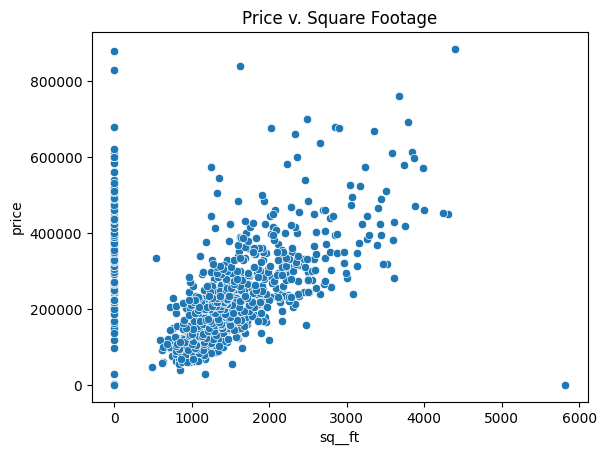

```python
sns.scatterplot(data=df, x='sq__ft', y='price')
plt.title('Price v. Square Footage')
```

It can be observed from the scatterplot that there appears to be a linear relationship between square footage and price for properties with square footage greater than zero. For properties with a square footage of zero the relationship between the price appears to be an increasing vertical line where sq__ft equals zero.

##### **Scatterplot: Price v. latitude**

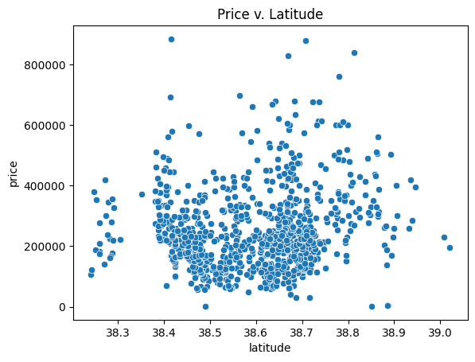

```python
sns.scatterplot(data=df, x='latitude', y='price')
plt.title('Price v. Latitude')
```

It can be observed from the scatterplot above that there is little to no correlation between the latitude and price variable, so latititude is not predictive of price.

##### **Scatterplot: Price v. Longitude**

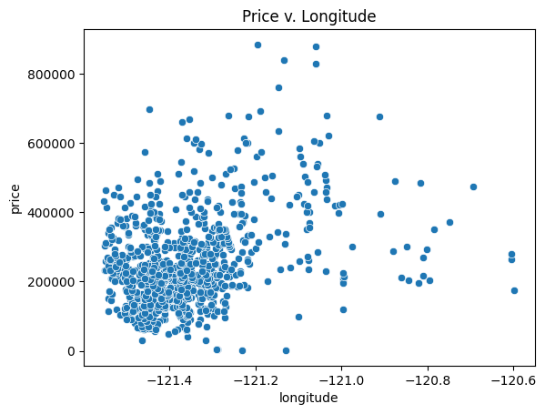

```python
sns.scatterplot(data=df, x='longitude', y='price')
plt.title('Price v. Longitude')
```

It can be observed from the scatterplot above that there is little correlation between the longitude and price variable, so longitude is not predictive of price.

For each categorical variable, create a box plot of the categorical variable versus price.

##### **Street type**

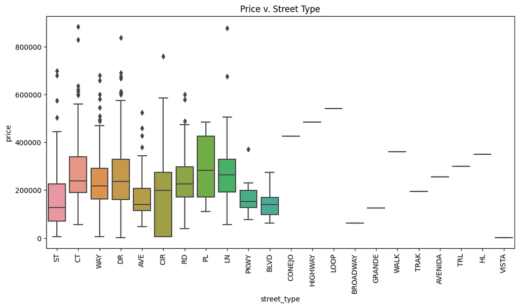

```python
plot = sns.boxplot(data=df, x='street_type', y='price')
plot.set_xticklabels(plot.get_xticklabels(), rotation=90)
plot.figure.set_size_inches(12,6)
plt.title('Price v. Street Type')
```

Based on the box plot above, we can conclude that street type is predictive of price. The distributions of the price for various street types are different which indicates that street type may be predictive of the price of a property.

##### **Type**

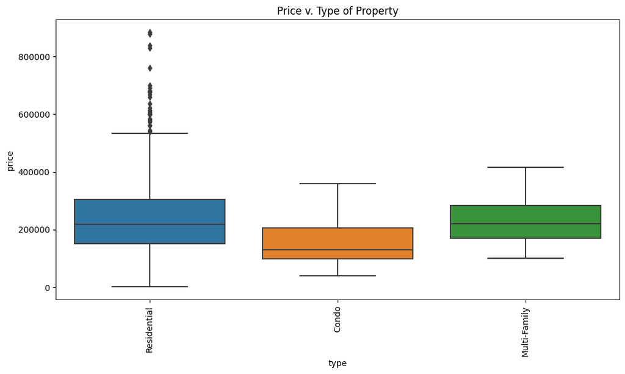

```python
plot = sns.boxplot(data=df, x='type', y='price')
plot.set_xticklabels(plot.get_xticklabels(), rotation=90)
plot.figure.set_size_inches(12,6)
plt.title('Price v. Type of Property')
```

From the plot above, we can observe that the distributions of data of the type categories are somewhat different. This indicates that the type of property could potentiallly be predictive of the price of a property.

##### **Number of baths**

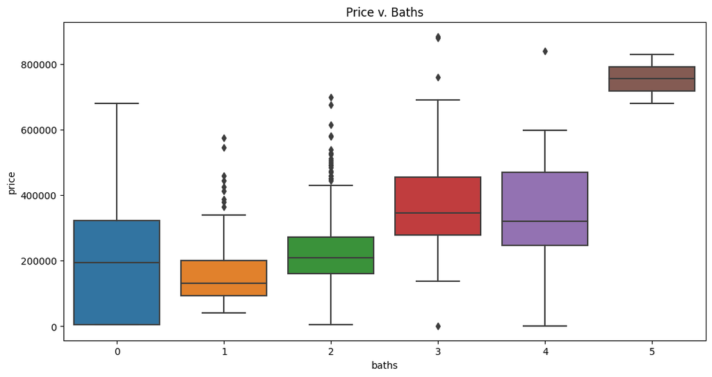

```python
plot = sns.boxplot(data=df, x='baths', y='price')
plot.figure.set_size_inches(12,6)
plt.title('Price v. Baths')
```

It can be observed from the plot above, that the distributions of each of the baths categories are different. This indicates that the number of baths of a property is predictive of the price of a property.

##### **Number of beds**

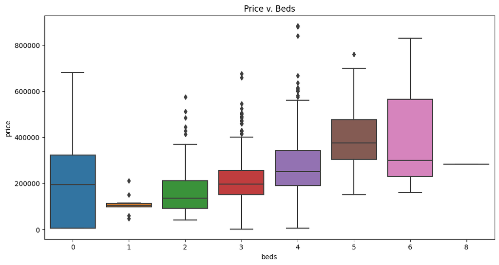

```python
plot = sns.boxplot(data=df, x='beds', y='price')
plot.figure.set_size_inches(12,6)
plt.title('Price v. Beds')
```

It can be observed from the plot above, that the distributions of each of the beds categories are different. This indicates that the number of beds of a property is predictive of the price of a property.

##### **Zip code**

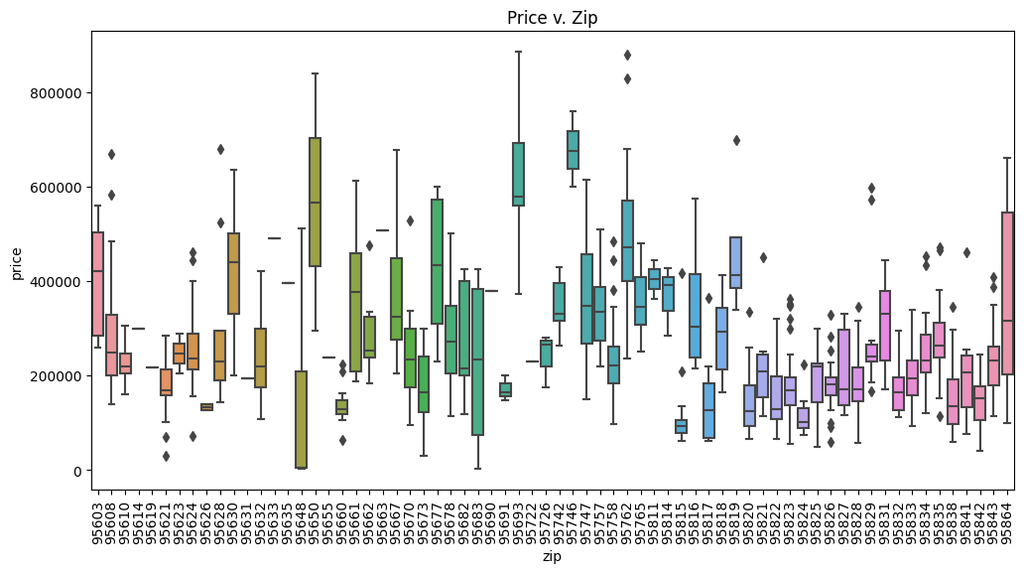

```python
plot = sns.boxplot(data=df, x='zip', y='price')
plot.set_xticklabels(plot.get_xticklabels(), rotation=90)
plot.figure.set_size_inches(12,6)
plt.title('Price v. Zip')
```

It can be observed from the plot above, that the distributions of each of the zip codes are different from each other. This indicates that the zip code of a property is predictive of the price of a property. For example, the price distribution for the zip code 95815 is around $75,000 to $125,000 compared to the price distribution for the zip code 95746 is around $600,000 to $700,000 which means we can use the zip code to predict the price of a property.

##### **State**

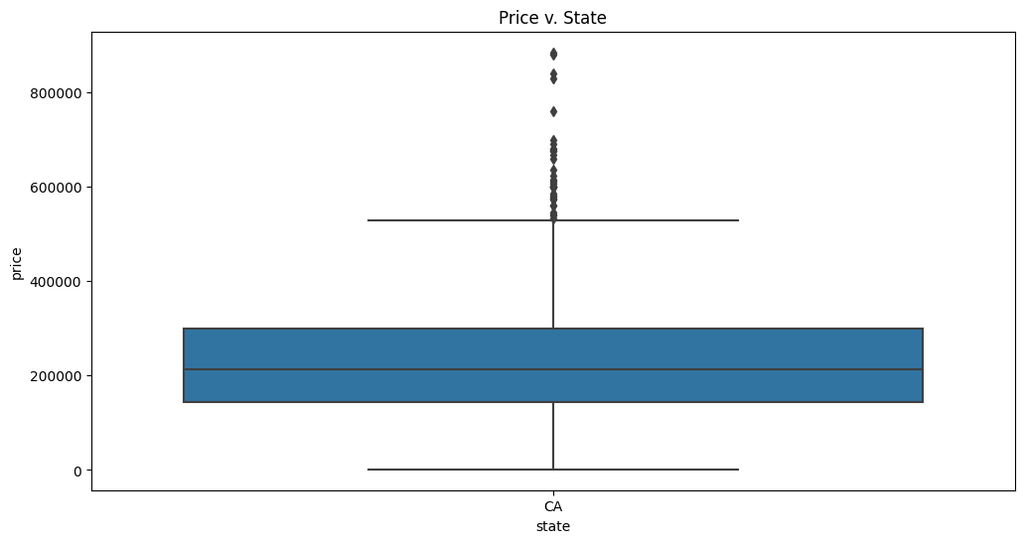

```python
plot = sns.boxplot(data=df, x='state', y='price')
plot.figure.set_size_inches(12,6)
plt.title('Price v. State')
```

Since the data is sampled from Sacremento, California there is only one state value for all of the data. Therefore, the state variable is not useful for predicting the price or any other target variable using this dataset.

##### **City**

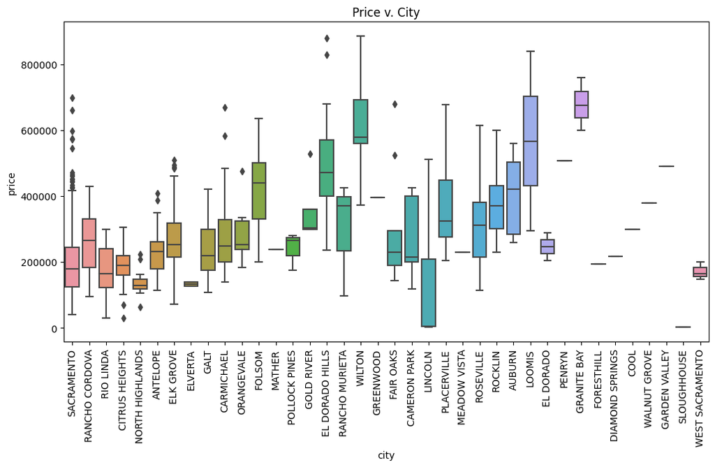

```python
plot = sns.boxplot(data=df, x='city', y='price')
plot.set_xticklabels(plot.get_xticklabels(), rotation=90)
plot.figure.set_size_inches(12,6)
plt.title('Price v. City')
```

It can be observed from the plot above, that the distributions of each of the cities are different from each other. This indicates that the city a property is in is predictive of the price of a property. For example, the price distribution of West Sacremento is around $150,000 to $200,000 and the price distribution of Granite Bay is around $600,000 to $700,000, so we use this to predict the price of properties based on the city they are in.

### **Part II - Classification on Property Type**

We will now explore which variables are predictive of the target value 'type' which represents the property type.

- For each continuous variable, create a box plot of the continuous variable versus property type.

##### **Price**

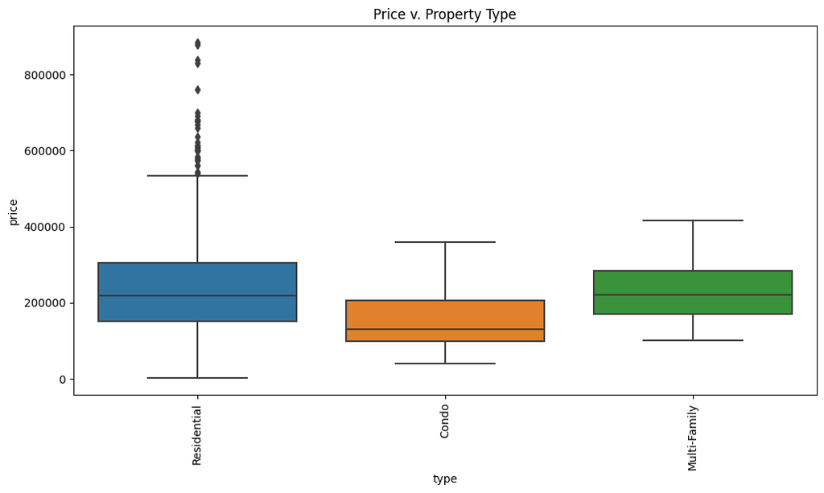

```python
plot = sns.boxplot(data=df, x='type', y='price')
plot.set_xticklabels(plot.get_xticklabels(), rotation=90)
plot.figure.set_size_inches(12,6)
plt.title('Price v. Property Type')
```

From the plot above, we can observe that the distributions of data of the type categories are somewhat different. This indicates that the price of the property could potentiallly be predictive of the type of a property.

##### **Square footage**

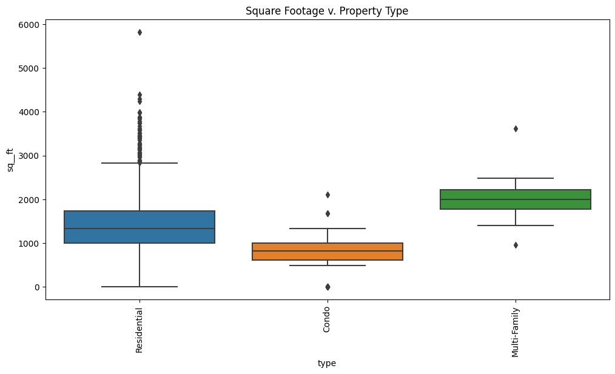

```python
plot = sns.boxplot(data=df, x='type', y='sq__ft')
plot.set_xticklabels(plot.get_xticklabels(), rotation=90)
plot.figure.set_size_inches(12,6)
plt.title('Square Footage v. Property Type')
```

We can observe from the plot above, that the distributions of each of the property types are different. This means that the square footage of a property is predictive of the type of a property.

##### **Latitude**

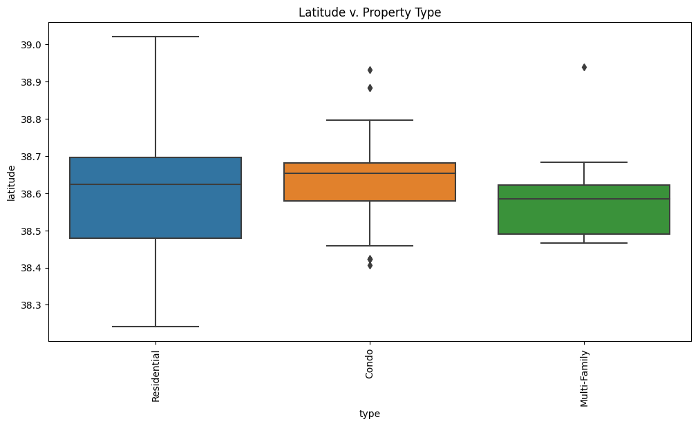

```python
plot = sns.boxplot(data=df, x='type', y='latitude')
plot.set_xticklabels(plot.get_xticklabels(), rotation=90)
plot.figure.set_size_inches(12,6)
plt.title('Latitude v. Property Type')
```

From the plot above, we can see that the distributions of the different property types are very similar. Therefore, the latitude of the property does not predict the type of property.

##### **Longitude**

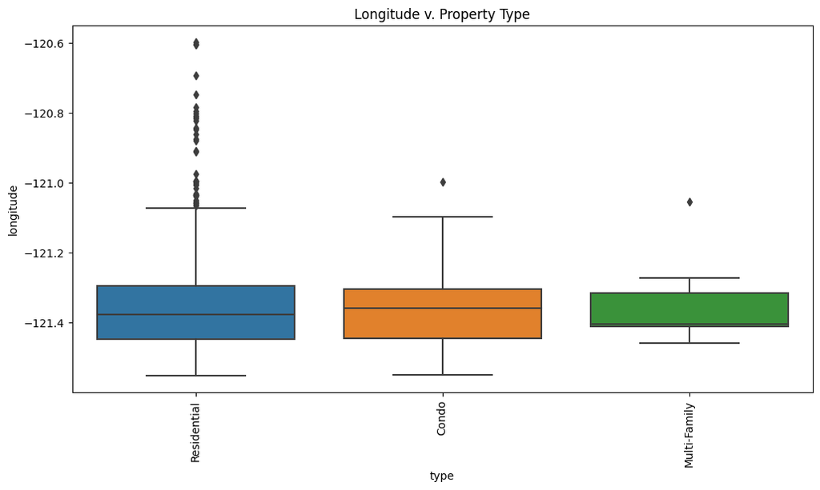

```python
plot = sns.boxplot(data=df, x='type', y='longitude')
plot.set_xticklabels(plot.get_xticklabels(), rotation=90)
plot.figure.set_size_inches(12,6)
plt.title('Longitude v. Property Type')
```

From the plot above, we can see that the distributions of the different property types are very similar. Therefore, the longitude of the property does not predict the type of property.

##### For each categorical variable, create a cross-tabulation table that shows the counts of each categorical variable value for each property type. For each categorical feature, visualize the normalized cross-tabulation table using a bar plot for each possible property type

##### **Contingency table for city**

```python
city_table = pd.crosstab(df['city'], df['type'], normalize='columns')
display(city_table)
```

| type city | Condo | Multi-Family | Residential |
| --- | --- | --- | --- |
| ANTELOPE | 0.018519 | 0.000000 | 0.034896 |
| AUBURN | 0.018519 | 0.076923 | 0.003272 |
| CAMERON PARK | 0.018519 | 0.000000 | 0.008724 |
| CARMICHAEL | 0.055556 | 0.000000 | 0.018539 |
| CITRUS HEIGHTS | 0.037037 | 0.076923 | 0.034896 |
| COOL | 0.000000 | 0.000000 | 0.001091 |
| DIAMOND SPRINGS | 0.000000 | 0.000000 | 0.001091 |
| EL DORADO | 0.000000 | 0.000000 | 0.002181 |
| EL DORADO HILLS | 0.000000 | 0.000000 | 0.025082 |
| ELK GROVE | 0.111111 | 0.000000 | 0.117775 |
| ELVERTA | 0.000000 | 0.000000 | 0.004362 |
| FAIR OAKS | 0.018519 | 0.000000 | 0.008724 |
| FOLSOM | 0.018519 | 0.000000 | 0.017448 |
| FORESTHILL | 0.000000 | 0.000000 | 0.001091 |
| GALT | 0.000000 | 0.000000 | 0.022901 |
| GARDEN VALLEY | 0.000000 | 0.000000 | 0.001091 |
| GOLD RIVER | 0.018519 | 0.000000 | 0.003272 |
| GRANITE BAY | 0.000000 | 0.000000 | 0.003272 |
| GREENWOOD | 0.000000 | 0.000000 | 0.001091 |
| LINCOLN | 0.037037 | 0.000000 | 0.076336 |
| LOOMIS | 0.000000 | 0.000000 | 0.002181 |
| MATHER | 0.000000 | 0.000000 | 0.001091 |
| MEADOW VISTA | 0.000000 | 0.000000 | 0.001091 |
| NORTH HIGHLANDS | 0.000000 | 0.000000 | 0.022901 |
| ORANGEVALE | 0.000000 | 0.000000 | 0.011996 |
| PENRYN | 0.000000 | 0.000000 | 0.001091 |
| PLACERVILLE | 0.000000 | 0.000000 | 0.010905 |
| POLLOCK PINES | 0.000000 | 0.000000 | 0.003272 |
| RANCHO CORDOVA | 0.018519 | 0.076923 | 0.028353 |
| RANCHO MURIETA | 0.000000 | 0.000000 | 0.003272 |
| RIO LINDA | 0.000000 | 0.000000 | 0.014177 |
| ROCKLIN | 0.000000 | 0.000000 | 0.018539 |
| ROSEVILLE | 0.129630 | 0.000000 | 0.044711 |
| SACRAMENTO | 0.500000 | 0.769231 | 0.438386 |
| SLOUGHHOUSE | 0.000000 | 0.000000 | 0.001091 |
| WALNUT GROVE | 0.000000 | 0.000000 | 0.001091 |
| WEST SACRAMENTO | 0.000000 | 0.000000 | 0.003272 |
| WILTON | 0.000000 | 0.000000 | 0.005453 |

Bar plot for city contingency table

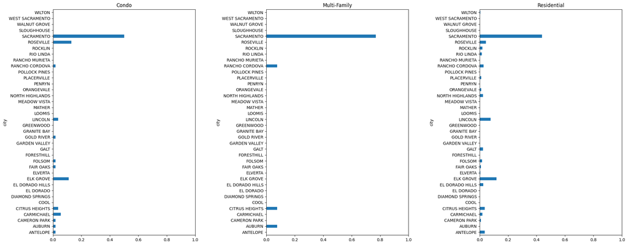

```python
fig, axs = plt.subplots(1, 3, figsize=(25,10))
fig.subplots_adjust(wspace=0.5)

types = ['Condo', 'Multi-Family', 'Residential']

for i, prop_type in enumerate(types):
    city_table[prop_type].plot.barh(ax=axs[i])
    axs[i].set_xlim([0,1])
    axs[i].set_title(prop_type)
    axs[i].set_ylabel('city')
```

We can see from each of the bar plots above, the distributions of the type of properties in each city are somewhat different. From this, we can conclude that the city can potentially predict the type of property.

##### **Contingency table for state**

```python
state_table = pd.crosstab(df['state'], df['type'], normalize='columns')
display(state_table)
```

| type state | Condo | Multi-Family | Residential |
| --- | --- | --- | --- |
| CA | 1.0 | 1.0 | 1.0 |

Bar plot for state contingency table

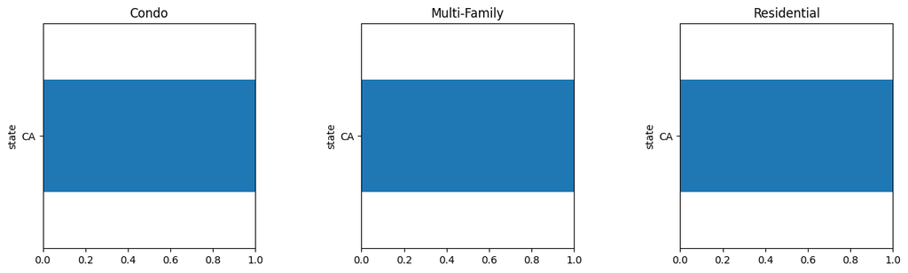

```python
fig, axs = plt.subplots(1, 3, figsize=(15,4))
fig.subplots_adjust(wspace=0.5)

types = ['Condo', 'Multi-Family', 'Residential']

for i, prop_type in enumerate(types):
    state_table[prop_type].plot.barh(ax=axs[i])
    axs[i].set_xlim([0,1])
    axs[i].set_title(prop_type)
    axs[i].set_ylabel('state')
```

Since the data is sampled from Sacremento, California there is only one state value for all of the data. Therefore, the state variable is not useful for predicting the type of property or any other target variable using this dataset.

##### **Contingency table for zip**

```python
zip_table = pd.crosstab(df['zip'], df['type'], normalize='columns')
display(zip_table)
```

| type zip | Condo | Multi-Family | Residential |
| --- | --- | --- | --- |
| 95603 | 0.018519 | 0.076923 | 0.003272 |
| 95608 | 0.055556 | 0.000000 | 0.018539 |
| 95610 | 0.000000 | 0.076923 | 0.006543 |
| 95614 | 0.000000 | 0.000000 | 0.001091 |
| 95619 | 0.000000 | 0.000000 | 0.001091 |
| ... | ... | ... | ... |
| 95838 | 0.000000 | 0.000000 | 0.040349 |
| 95841 | 0.055556 | 0.000000 | 0.004362 |
| 95842 | 0.092593 | 0.076923 | 0.017448 |
| 95843 | 0.018519 | 0.000000 | 0.034896 |
| 95864 | 0.000000 | 0.000000 | 0.005453 |

68 rows × 3 columns

Bar plot for zip contingency table

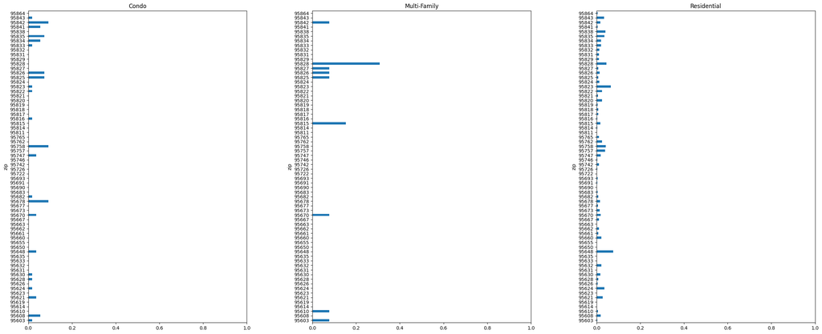

```python
fig, axs = plt.subplots(1, 3, figsize=(30,12))
fig.subplots_adjust(wspace=0.3)

types = ['Condo', 'Multi-Family', 'Residential']

for i, prop_type in enumerate(types):
    zip_table[prop_type].plot.barh(ax=axs[i])
    axs[i].set_xlim([0,1])
    axs[i].set_title(prop_type)
    axs[i].set_ylabel('zip')
    axs[i].set_yticklabels(axs[i].get_yticklabels(), fontsize=10)
```

We can see from each of the bar plots above, the distributions of the type of properties in each zip code are somewhat different. From this, we can conclude that the zip code can potentially predict the type of property, but most likely not very well.

##### **Contingency table for number of beds**

```python
beds_table = pd.crosstab(df['beds'], df['type'], normalize='columns')
display(beds_table)
```

| type beds | Condo | Multi-Family | Residential |
| --- | --- | --- | --- |
| 0 | 0.148148 | 0.000000 | 0.107961 |
| 1 | 0.166667 | 0.000000 | 0.001091 |
| 2 | 0.555556 | 0.076923 | 0.111232 |
| 3 | 0.129630 | 0.000000 | 0.442748 |
| 4 | 0.000000 | 0.615385 | 0.272628 |
| 5 | 0.000000 | 0.153846 | 0.062159 |
| 6 | 0.000000 | 0.076923 | 0.002181 |
| 8 | 0.000000 | 0.076923 | 0.000000 |

Bar plot of number of beds contingency table

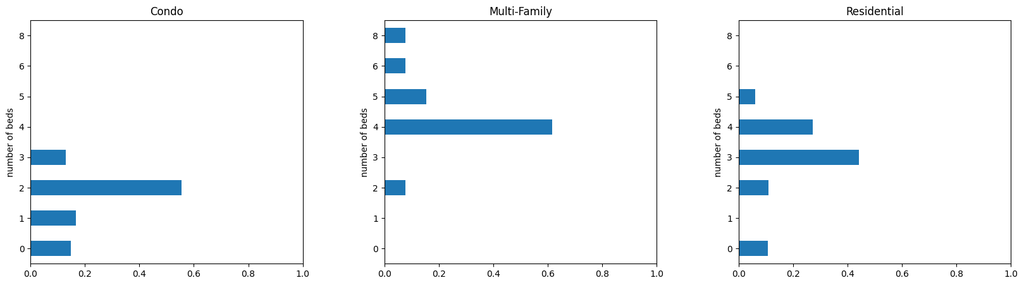

```python
fig, axs = plt.subplots(1, 3, figsize=(20,5))
fig.subplots_adjust(wspace=0.3)

types = ['Condo', 'Multi-Family', 'Residential']

for i, prop_type in enumerate(types):
    beds_table[prop_type].plot.barh(ax=axs[i])
    axs[i].set_xlim([0,1])
    axs[i].set_title(prop_type)
    axs[i].set_ylabel('number of beds')
```

We can see from each of the bar plots above, the distributions of the type of properties with a different number of beds are very different. From this, we can conclude that the number of beds can predict the type of property.

##### **Contingency table for number of baths**

```python
baths_table = pd.crosstab(df['baths'], df['type'], normalize='columns')
display(baths_table)
```

| type baths | Condo | Multi-Family | Residential |
| --- | --- | --- | --- |
| 0 | 0.148148 | 0.000000 | 0.107961 |
| 1 | 0.462963 | 0.000000 | 0.169029 |
| 2 | 0.388889 | 0.461538 | 0.563795 |
| 3 | 0.000000 | 0.000000 | 0.143948 |
| 4 | 0.000000 | 0.538462 | 0.013086 |
| 5 | 0.000000 | 0.000000 | 0.002181 |

Bar plot of baths contingency table

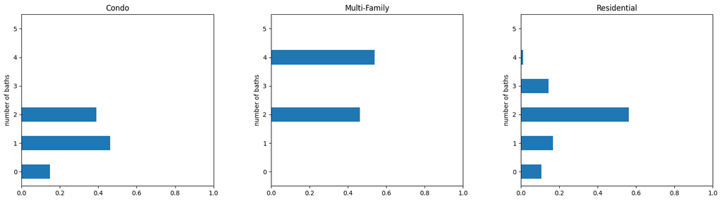

```python
fig, axs = plt.subplots(1, 3, figsize=(20,5))
fig.subplots_adjust(wspace=0.3)

types = ['Condo', 'Multi-Family', 'Residential']

for i, prop_type in enumerate(types):
    baths_table[prop_type].plot.barh(ax=axs[i])
    axs[i].set_xlim([0,1])
    axs[i].set_title(prop_type)
    axs[i].set_ylabel('number of baths')
```

We can see from each of the bar plots above, the distributions of the type of properties with a different number of baths are very different. From this, we can conclude that the number of baths can predict the type of property.

##### **Contingency table for street type**

```python
street_table = pd.crosstab(df['street_type'], df['type'], normalize='columns')
display(street_table)
```

| type street_type | Condo | Multi-Family | Residential |
| --- | --- | --- | --- |
| AVE | 0.018519 | 0.076923 | 0.078517 |
| AVENIDA | 0.000000 | 0.000000 | 0.001091 |
| BLVD | 0.074074 | 0.076923 | 0.008724 |
| BROADWAY | 0.000000 | 0.000000 | 0.001091 |
| CIR | 0.037037 | 0.153846 | 0.118866 |
| CONEJO | 0.000000 | 0.000000 | 0.001091 |
| CT | 0.074074 | 0.076923 | 0.131952 |
| DR | 0.370370 | 0.076923 | 0.163577 |
| GRANDE | 0.000000 | 0.000000 | 0.001091 |
| HIGHWAY | 0.000000 | 0.000000 | 0.001091 |
| HL | 0.018519 | 0.000000 | 0.000000 |
| LN | 0.166667 | 0.000000 | 0.040349 |
| LOOP | 0.000000 | 0.000000 | 0.001091 |
| PKWY | 0.055556 | 0.000000 | 0.004362 |
| PL | 0.018519 | 0.153846 | 0.007634 |
| RD | 0.055556 | 0.153846 | 0.025082 |
| ST | 0.037037 | 0.000000 | 0.087241 |
| TRAK | 0.000000 | 0.000000 | 0.001091 |
| TRL | 0.000000 | 0.000000 | 0.001091 |
| VISTA | 0.000000 | 0.000000 | 0.001091 |
| WALK | 0.018519 | 0.000000 | 0.000000 |
| WAY | 0.055556 | 0.230769 | 0.323882 |

Bar plot of the street type contingency table

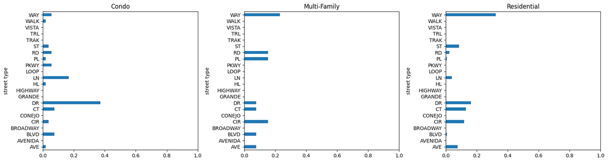

```python
fig, axs = plt.subplots(1, 3, figsize=(20,5))
fig.subplots_adjust(wspace=0.3)

types = ['Condo', 'Multi-Family', 'Residential']

for i, prop_type in enumerate(types):
    street_table[prop_type].plot.barh(ax=axs[i])
    axs[i].set_xlim([0,1])
    axs[i].set_title(prop_type)
    axs[i].set_ylabel('street type')
```

### **Part III - Compare Predictive Variables**

| **Variable** | **Predictive for Price** | **Predictive for Property Type** |
| --- | --- | --- |
| sq__ft | Yes | Yes |
| baths | Yes | Yes |
| beds | Yes | Yes |
| city | Yes | Yes |
| zip | Yes | Maybe |
| street_type | Yes | No |
| state | No | No |
| latitude | No | No |
| longitude | No | No |
| price | N/A | Yes |
| type | Yes | N/A |

[output not shown]